# Portfolio 3.1

# MINI EXERCISE 4

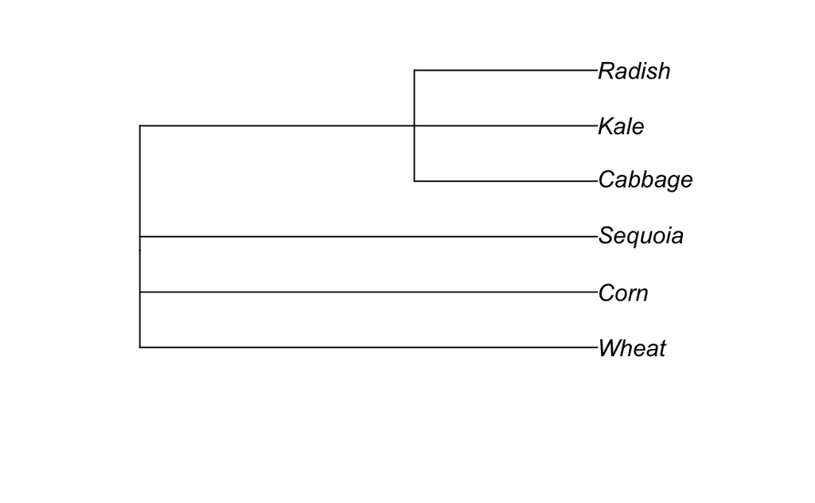

```r
#plotting 6 taxa in different formats
plot(tr3_plants, type="phylogram")
```

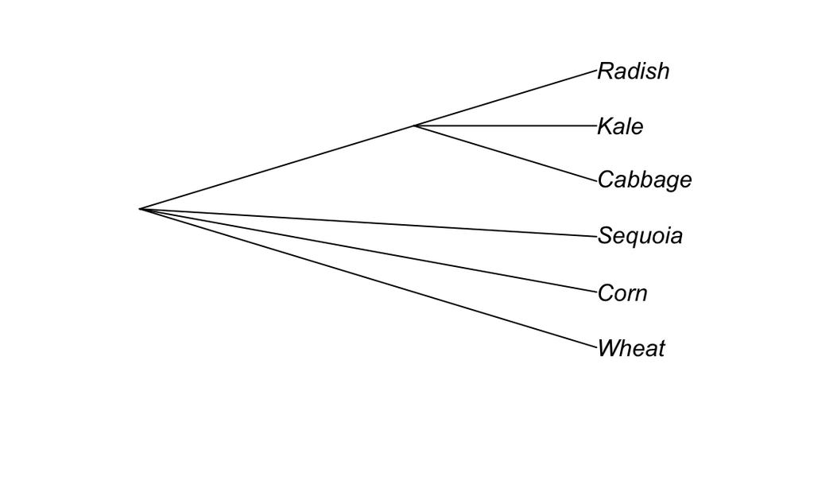

```r
plot(tr3_plants, type="cladogram")
```

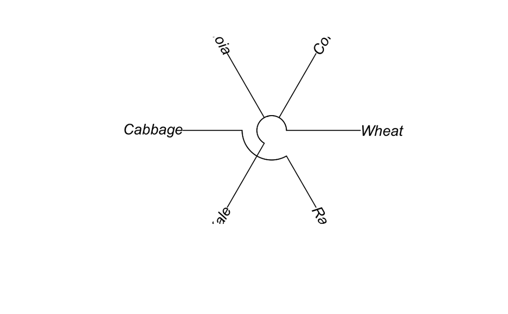

```r
plot(tr3_plants, type="fan")
```

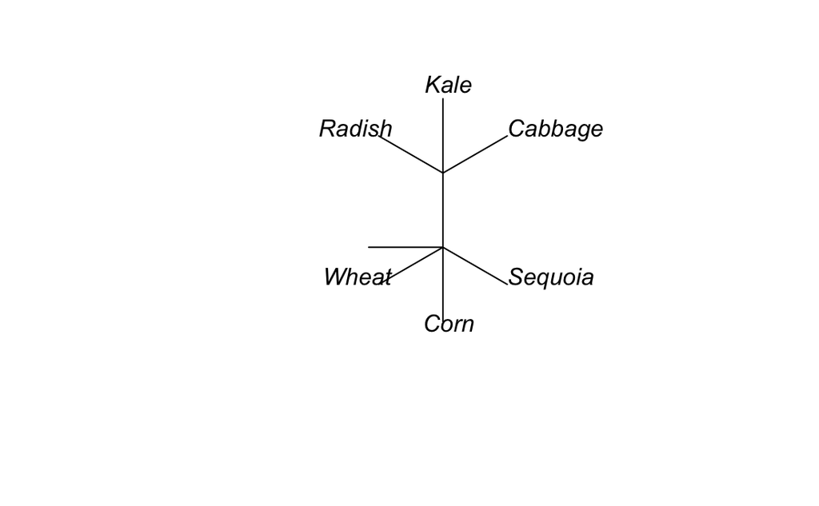

```r
plot(tr3_plants, type="unrooted")
```

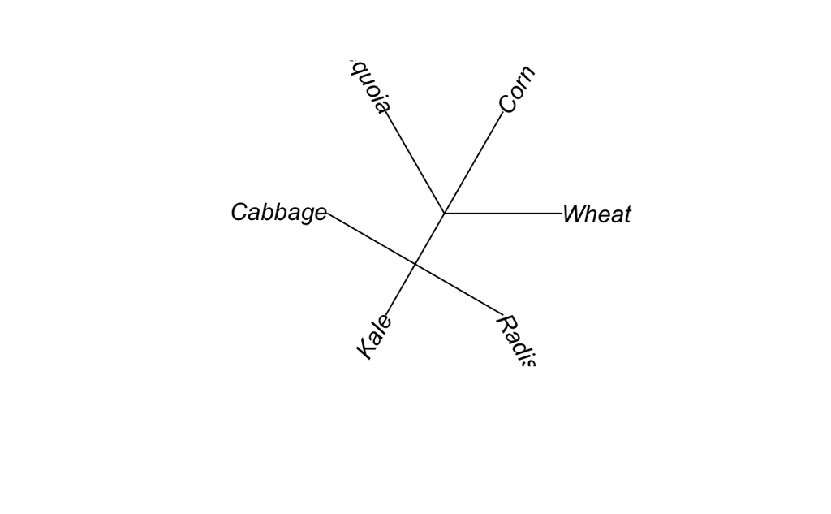

```r
plot(tr3_plants, type="radial")
```

# MINI EXERCISE 5

```r
#plotting phylogram instead of cladogram
EG<-c("Abies",
"Ailanthus",
"Aspicllum",
"Atragene",
"Bangia",
"Begonia",
"Berberis",
"Betula",
"Blasia",
"Blechnum",
"Caulerpa",
"Ceratophyllum",
"Chenopodium",
"Clematis",
"Cocculus",
"Corallorrhiza",
"Corchorus",
"Cucurbita",
"Dahlia",
"Dioscorea",
"Dracaena",
"Equisetum",
"Euonymus",
"Euphorbia",
"Fagus",
"Ficus",
"Fontinalis",
"Fossombronia",
"Fritillaria",
"Fucus",
"Gleditschia",
"Gleocapsa",
"Haplomitrium",
"Hedera",
"Helianthus",
"Heterocentron",
"Hippuris",
"Hypoderma",
"Isoetes",
"Linum",
"Liquidambar",
"Marchantia",
"Momordica",
"Monopodium",
"Mucor",
"Nerium",
"Nitella",
"Osmunda",
"Pandanus",
"Papaver",
"Pelargonium",
"Phlomis",
"Phytolacca",
"Pinus",
"Platanus",
"Polytrichum",
"Populus",
"Potamogeton",
"Punctum",
"Quercus",
"Ricinus",
"Rubus",
"Salix",
"Sambucus",
"Sclerotium",
"Selaginella",
"Sempervivum",
"Sponia",
"Stypocaulon",
"Sympodium",
"Taxodium",
"Tecoma",
"Tradescantia",
"Urtica",
"Viola",
"Vitis",
"Wisteria",
"Yucca")
EG
```

```
 [1] "Abies"         "Ailanthus"     "Aspicllum"     "Atragene"      "Bangia"
 [6] "Begonia"       "Berberis"      "Betula"        "Blasia"        "Blechnum"
[11] "Caulerpa"      "Ceratophyllum" "Chenopodium"   "Clematis"      "Cocculus"
[16] "Corallorrhiza" "Corchorus"     "Cucurbita"     "Dahlia"        "Dioscorea"
[21] "Dracaena"      "Equisetum"     "Euonymus"      "Euphorbia"     "Fagus"
[26] "Ficus"         "Fontinalis"    "Fossombronia"  "Fritillaria"   "Fucus"
[31] "Gleditschia"   "Gleocapsa"     "Haplomitrium"  "Hedera"        "Helianthus"
[36] "Heterocentron" "Hippuris"      "Hypoderma"     "Isoetes"       "Linum"
[41] "Liquidambar"   "Marchantia"    "Momordica"     "Monopodium"    "Mucor"
[46] "Nerium"        "Nitella"       "Osmunda"       "Pandanus"      "Papaver"
[51] "Pelargonium"   "Phlomis"       "Phytolacca"    "Pinus"         "Platanus"
[56] "Polytrichum"   "Populus"       "Potamogeton"   "Punctum"       "Quercus"
[61] "Ricinus"       "Rubus"         "Salix"         "Sambucus"      "Sclerotium"
[66] "Selaginella"   "Sempervivum"   "Sponia"        "Stypocaulon"   "Sympodium"
[71] "Taxodium"      "Tecoma"        "Tradescantia"  "Urtica"        "Viola"
[76] "Vitis"         "Wisteria"      "Yucca"
```

```r
ree_phylomatic_EG1 <- phylomatic(taxa = EG, get = 'POST')
```

```
NOTE: 26 taxa not matched: NA/aspicllum/aspicllum, NA/bangia/bangia, NA/blasia/blasia, NA/blechnum/blechnum, NA/caulerpa/caulerpa, NA/corallorrhiza/corallorrhiza, NA/equisetum/equisetum, NA/fontinalis/fontinalis, NA/fossombronia/fossombronia, NA/fucus/fucus, NA/gleditschia/gleditschia, NA/gleocapsa/…
```

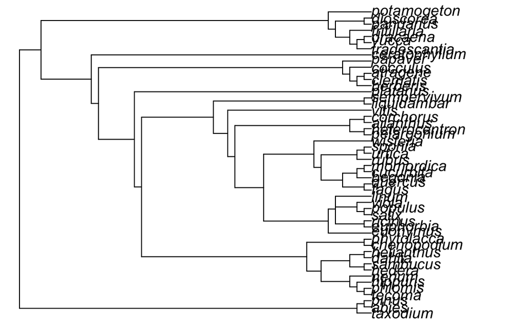

```r
plot(tree_phylomatic_EG1, no.margin = TRUE, type="phylogram")
```

```r
newick_fn4 = "tree_phylomatic_EG1"
write.tree(tree_phylomatic_EG1, file=newick_fn4)
#repeating to get tree from Zanne2014
tree_phylomatic_EG2 <- phylomatic(taxa = EG, storedtree ="zanne2014", get = 'POST')
```

```
NOTE: 30 taxa not matched: pinaceae/abies/abies, NA/aspicllum/aspicllum, NA/bangia/bangia, NA/blasia/blasia, NA/blechnum/blechnum, NA/caulerpa/caulerpa, ceratophyllaceae/ceratophyllum/ceratophyllum, NA/corallorrhiza/corallorrhiza, NA/equisetum/equisetum, NA/fontinalis/fontinalis, NA/fossombronia/fos…
```

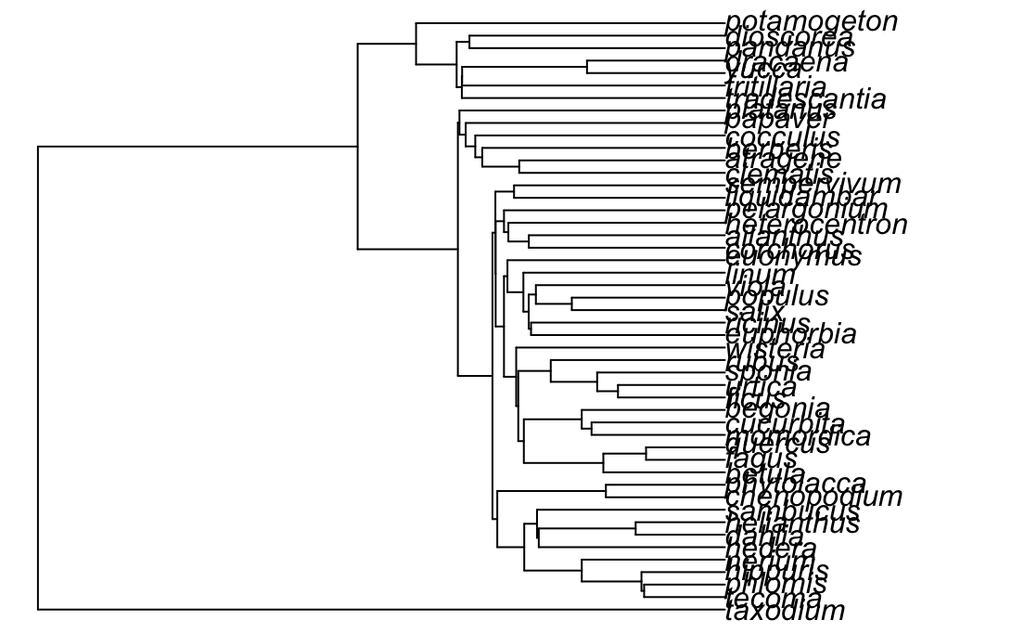

```r
plot(tree_phylomatic_EG2, no.margin = TRUE, type="phylogram")
```

```r
newick_fn5 = "tree_phylomatic_EG2"
write.tree(tree_phylomatic_EG2, file=newick_fn5)
```

Here we took our the species from Emily Gregory’s list and plotted them as a phylogram instead of a cladogram, which can be seen by the non v shaped differeing branch lengths. The difference between the cladogram that was plotted in the exercercise and this phylogram simply represents the data that allows us to interpret the information differently. For example, the cladogram contains branches of similar lenghts, whereas the phylogram contains branches of many differening lenghts, this means that the cladogram is good for determining common ancestors, but if we wanted to have a more accurate representation of WHEN evolutionary taxa separated, we would be a better of looking at a phylogram. We can also see what is missing from the tree,sclerotium, is a type of vegetative fungus that mainly develop on trees, but can sometimes fall off and go dormant by accumulating food reserves. The fact that this was not included in the tree could mean that Botanists are still researching the nature of sclerotium in order to properly categorize it. For example, upon research I found out that scientists first believed that sclerotium were mistaken for individuals, until it was found out that this is a stage in a life cycle that some fungi go through… This shows that there is still research to be done on the nature of plants to create a complete phylogenetic tree. #MACRO ASSIGNMENT

```r
#we are going to make a tree using a list of the plants I use on a daily basis
spp1 <- c("Camellia sinensis", "Matricaria chamomilla", "Spinacia oleracea", "Capsicum annuum",
"Brassica oleracea", "Coriandrum sativum", "Gossypium hirsutum", "Cicer arietinum", "Pisum sativum", "Citrus maxima", "Allium_schoenoprasum", "Vitis vinifera", "Theobroma cacao", "Glycine Max", "Helianthus annus", "Vitis rotundifolia","Citrus limon", "Vitis amurensis","Vitis labruscana", "Coffea arabica", "Citrus sinensis", "Citrus reticulata", "Prunus serrulata", "Ficus carica", "Triticum aestivum", "Quercus Alba", "Allium cepa", "Ocimum basilicum", "Solanum tuberosum", "Musa ornata")
#shortcut to get the evolutionary relationship data
urlA<-"http://datadryad.org/bitstream/handle/10255/dryad.8791/final_tree.tre?sequence=1"
#plotting
daily<-phylomatic(taxa=spp1, treeuri=urlA)
```

```
NOTE: 4 taxa not matched: amaryllidaceae/allium_schoenoprasum/allium_schoenoprasum, asteraceae/helianthus/helianthus_annus, vitaceae/vitis/vitis_amurensis, vitaceae/vitis/vitis_labruscana, ];
```

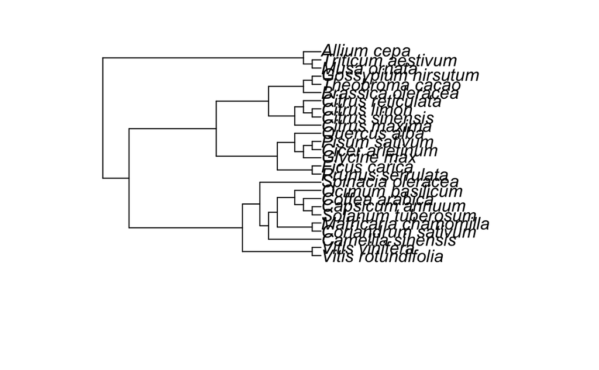

```r
plot(daily)
```

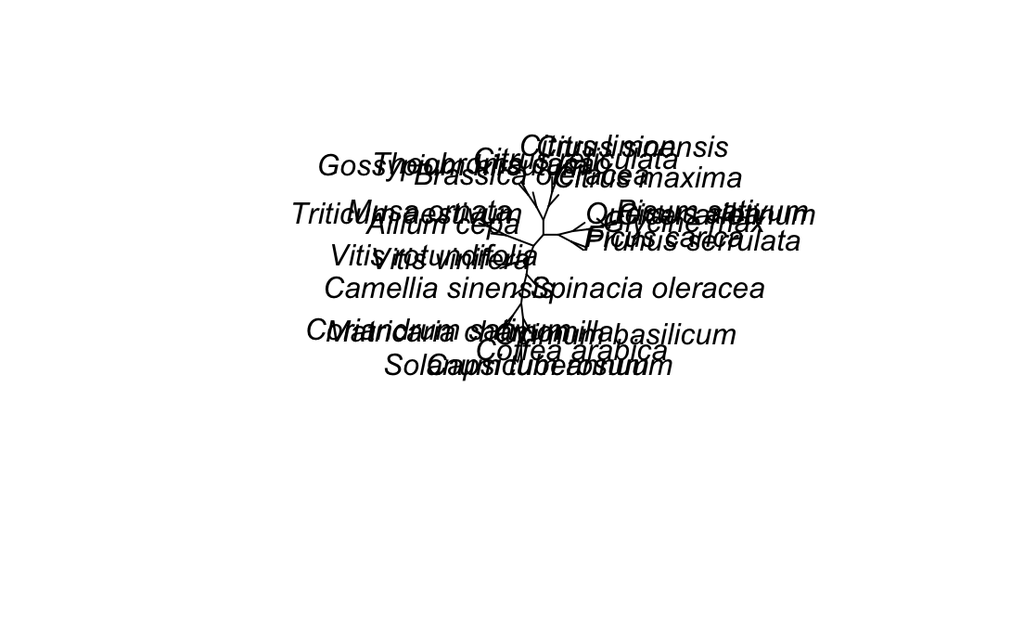

```r
plot(daily, type="unrooted")
```

```r
plot(daily, type="cladogram")
pdf_fn = "daily.pdf"
pdf(file=pdf_fn)
```

[figure not shown]

```r
plot(daily, type="unrooted", edge.width=5, edge.color="blue", lab4ut="axial")
dev.off()
```